# IMT 573 - Final Examination

Points: 100

Name: Bidyut Prava Ojha

### Instructions

This is a take-home final examination. You may use your computer, books/articles, notes, course materials, etc., but all work must be your own! Please review the course policy on AI-based learning tools. References must be appropriately cited. Please justify your answers and show all work; a complete argument must be presented to obtain full credit. Before beginning this exam, please ensure you have access to data programming environments used in the course; this can be on your own personal computer or on shared infrastructure hosted by the university.

1. Download the exam template notebook file from Canvas. Open exam notebook and supply your solutions to the exam by editing the notebook.
2. Be sure the exam contains your full name.
3. Be sure to include well-documented (e.g. commented) code chucks, figures, and clearly written text chunk explanations as necessary. Any figures should be clearly labeled and appropriately referenced within the text. Be sure that each visualization adds value to your written explanation; avoid redundancy -- you do not need four different visualizations of the same pattern.
4. **Collaboration is not allowed on this exam. You may only speak with the course instructor about this material.**
5. All materials and resources that you use (with the exception of lecture slides) must be appropriately referenced within your assignment.
6. Remember partial credit will be awarded for each question for which a serious attempt at finding an answer has been shown. Students are **strongly** encouraged to attempt each question and to document their reasoning process even if they cannot find the correct answer. If you would like to include code to show this process, but it does not run without errors, you can do so by commenting out that code.
7. When you have completed the assignment and have **checked** that your code both runs in the Console and compiles correctly rename the file to `YourLastName_YourFirstName.ipynb`, and submit BOTH your HTML and notebook files on Canvas.

### Statement of Compliance

You **must** include the a "signed" Statement of Compliance in your submission. The Compliance Statement is found below. You must include this text, word-for-word, in your final exam submission. Adding your name indicates you have read the statement and agree to its terms. Failure to do so will result in your exam **not** being accepted.

**Statement of Compliance**

I affirm that I have had no conversation regarding this exam with any persons other than the instructor. Further, I certify that the attached work represents my own thinking. Any information, concepts, or words that originate from other sources are cited in accordance with University of Washington guidelines as published in the Academic Code (available on the course website). I am aware of the serious consequences that result from improper discussions with others or from the improper citation of work that is not my own.

Bidyut Prava Ojha

Nov 24,2025

For this assignment, you'll need (at least) the following packages. If the package does not load, be sure it is properly installed.

```python
import pandas as pd
import numpy as np
import matplotlib.pyplot as plt
import seaborn as sns
import statsmodels.api as sm
```

### Problem 1

Points: 20

In this problem we will use data on infidelity, known as the Fair's Affairs dataset. The `Affairs` dataset is available as part of the `datasets` package in`statsmodels`. This data comes from a survey conducted by Psychology Today in 1969, see Greene (2003) and Fair (1978) for more information.

The dataset contains various self-reported characteristics of 6366 participants, including how often the respondent engaged in extramarital sexual intercourse during the past year, as well as their gender, age, year married, whether they had children, their religiousness (on a 5-point scale, from 1=anti to 5=very), education, occupation (Hillingshead 7-point classification with reverse numbering), and a numeric self-rating of their marriage (from 1=very unhappy to 5=very happy).

(a) Describe the participants. Use descriptive, summarization, and exploratory techniques to describe the participants in the study. Tell us the average/mean of children count ? What is the average age of respondents? In your response comment on any ethical and privacy concerns you have with this dataset.

```python
affairs = sm.datasets.fair.load_pandas().data
print(sm.datasets.fair.NOTE)
```

```
::

    Number of observations: 6366
    Number of variables: 9
    Variable name definitions:

        rate_marriage   : How rate marriage, 1 = very poor, 2 = poor, 3 = fair,
                        4 = good, 5 = very good
        age             : Age
        yrs_married     : No. years married. Interval approximations. See
                        original paper for detailed explanation.
        children        : No. children
        religious       : How relgious, 1 = not, 2 = mildly, 3 = fairly,
                        4 = strongly
        educ            : Level of education, 9 = grade school, 12 = high
                        school, 14 = some college, 16 = college graduate,
                        17 = some graduate school, 20 = advanced degree
        occupation      : 1 = student, 2 = farming, agriculture; semi-skilled,
                        or unskilled worker; 3 = white-colloar; 4 = teacher
                        counselor social worker, nurse; artist, writers;
                        technician, skilled worker, 5 = managerial,
                        administrative, business, 6 = professional with
                        advanced degree
        occupation_husb : Husband's occupation. Same as occupation.
        affairs         : measure of time spent in extramarital affairs

    See the original paper for more details.
```

```python
affairs.head(20)
```

|  | rate_marriage | age | yrs_married | children | religious | educ | occupation | occupation_husb | affairs |
| --- | --- | --- | --- | --- | --- | --- | --- | --- | --- |
| 0 | 3.0 | 32.0 | 9.0 | 3.0 | 3.0 | 17.0 | 2.0 | 5.0 | 0.111111 |
| 1 | 3.0 | 27.0 | 13.0 | 3.0 | 1.0 | 14.0 | 3.0 | 4.0 | 3.230769 |
| 2 | 4.0 | 22.0 | 2.5 | 0.0 | 1.0 | 16.0 | 3.0 | 5.0 | 1.400000 |
| 3 | 4.0 | 37.0 | 16.5 | 4.0 | 3.0 | 16.0 | 5.0 | 5.0 | 0.727273 |
| 4 | 5.0 | 27.0 | 9.0 | 1.0 | 1.0 | 14.0 | 3.0 | 4.0 | 4.666666 |
| 5 | 4.0 | 27.0 | 9.0 | 0.0 | 2.0 | 14.0 | 3.0 | 4.0 | 4.666666 |
| 6 | 5.0 | 37.0 | 23.0 | 5.5 | 2.0 | 12.0 | 5.0 | 4.0 | 0.852174 |
| 7 | 5.0 | 37.0 | 23.0 | 5.5 | 2.0 | 12.0 | 2.0 | 3.0 | 1.826086 |
| 8 | 3.0 | 22.0 | 2.5 | 0.0 | 2.0 | 12.0 | 3.0 | 3.0 | 4.799999 |
| 9 | 3.0 | 27.0 | 6.0 | 0.0 | 1.0 | 16.0 | 3.0 | 5.0 | 1.333333 |
| 10 | 2.0 | 27.0 | 6.0 | 2.0 | 1.0 | 16.0 | 3.0 | 5.0 | 3.266665 |
| 11 | 5.0 | 27.0 | 6.0 | 2.0 | 3.0 | 14.0 | 3.0 | 5.0 | 2.041666 |
| 12 | 3.0 | 37.0 | 16.5 | 5.5 | 1.0 | 12.0 | 2.0 | 3.0 | 0.484848 |
| 13 | 5.0 | 27.0 | 6.0 | 0.0 | 2.0 | 14.0 | 3.0 | 2.0 | 2.000000 |
| 14 | 4.0 | 22.0 | 6.0 | 1.0 | 1.0 | 14.0 | 4.0 | 4.0 | 3.266665 |
| 15 | 4.0 | 37.0 | 9.0 | 2.0 | 2.0 | 14.0 | 3.0 | 6.0 | 1.361111 |
| 16 | 4.0 | 27.0 | 6.0 | 1.0 | 1.0 | 12.0 | 3.0 | 5.0 | 2.000000 |
| 17 | 1.0 | 37.0 | 23.0 | 5.5 | 4.0 | 14.0 | 5.0 | 2.0 | 1.826086 |
| 18 | 2.0 | 42.0 | 23.0 | 2.0 | 2.0 | 20.0 | 4.0 | 4.0 | 1.826086 |
| 19 | 4.0 | 37.0 | 6.0 | 0.0 | 2.0 | 16.0 | 5.0 | 4.0 | 2.041666 |

```python
# Summary of all numeric variables
affairs.describe()
```

|  | rate_marriage | age | yrs_married | children | religious | educ | occupation | occupation_husb | affairs |
| --- | --- | --- | --- | --- | --- | --- | --- | --- | --- |
| count | 6366.000000 | 6366.000000 | 6366.000000 | 6366.000000 | 6366.000000 | 6366.000000 | 6366.000000 | 6366.000000 | 6366.000000 |
| mean | 4.109645 | 29.082862 | 9.009425 | 1.396874 | 2.426170 | 14.209865 | 3.424128 | 3.850141 | 0.705374 |
| std | 0.961430 | 6.847882 | 7.280120 | 1.433471 | 0.878369 | 2.178003 | 0.942399 | 1.346435 | 2.203374 |
| min | 1.000000 | 17.500000 | 0.500000 | 0.000000 | 1.000000 | 9.000000 | 1.000000 | 1.000000 | 0.000000 |
| 25% | 4.000000 | 22.000000 | 2.500000 | 0.000000 | 2.000000 | 12.000000 | 3.000000 | 3.000000 | 0.000000 |
| 50% | 4.000000 | 27.000000 | 6.000000 | 1.000000 | 2.000000 | 14.000000 | 3.000000 | 4.000000 | 0.000000 |
| 75% | 5.000000 | 32.000000 | 16.500000 | 2.000000 | 3.000000 | 16.000000 | 4.000000 | 5.000000 | 0.484848 |
| max | 5.000000 | 42.000000 | 23.000000 | 5.500000 | 4.000000 | 20.000000 | 6.000000 | 6.000000 | 57.599991 |

```python
# Finding the average age of participants
avg_age = affairs['age'].mean()
max_age = affairs['age'].max()
min_age = affairs['age'].min()
print("Average age of participants:", avg_age)
print("Maximum age of participants:", max_age)
print("Minimum age of participants:", min_age)
print()
print()
```

```
Average age of participants: 29.082862079798932
Maximum age of participants: 42.0
Minimum age of participants: 17.5
```

```python
# Finding years of marriage of participants
max_years = affairs['yrs_married'].max()
min_years = affairs['yrs_married'].min()
avg_years = affairs['yrs_married'].mean()
print("Maximum years being married of participants :", max_years)
print("Minimum years being married of participants :", min_years)
print("Average years being married of participants :", avg_years)
print()
print()
```

```
Maximum years being married of participants : 23.0
Minimum years being married of participants : 0.5
Average years being married of participants : 9.00942507068803
```

```python
# Finding common profession of participants
most_common_job = affairs['occupation'].value_counts().idxmax()
job_counts = affairs['occupation'].value_counts()

print("Most common job held by participants:", most_common_job)
print("\nOccupation frequency table:")
print(job_counts) # Most participants belonged to white-collar job profession and 41 people were students
print()
print()
```

```
Most common job held by participants: 3.0

Occupation frequency table:
occupation
3.0    2783
4.0    1834
2.0     859
5.0     740
6.0     109
1.0      41
Name: count, dtype: int64
```

```python
# Finding common educational background of participants
most_common_education = affairs['educ'].value_counts().idxmax()
education_counts = affairs['educ'].value_counts()

print("\nMost common education level:", most_common_education)
print("\nEducation frequency table:")
print(education_counts) # most of people have some college level education
print()
print()
```

```
Most common education level: 14.0

Education frequency table:
educ
14.0    2277
12.0    2084
16.0    1117
17.0     510
20.0     330
9.0       48
Name: count, dtype: int64
```

```python
# Finding the articpants' religiousness
most_common_religion = affairs['religious'].value_counts().idxmax()
religion_counts = affairs['religious'].value_counts()

print("\nMost common religious level:", most_common_religion)
# Convert to percentages
religion_percentages = (religion_counts / len(affairs)) * 100
print("\nReligiousness frequency table:")
print(religion_counts) # Most people were fairly religious almost 38%
print("\nReligious Level Percentages:")
print(religion_percentages)
print()
print()
```

```
Most common religious level: 3.0

Religiousness frequency table:
religious
3.0    2422
2.0    2267
1.0    1021
4.0     656
Name: count, dtype: int64

Religious Level Percentages:
religious
3.0    38.045869
2.0    35.611059
1.0    16.038329
4.0    10.304744
Name: count, dtype: float64
```

```python
# Finding average no. of children of participants

avg_count_children = affairs['children'].mean()
max_count_children = affairs['children'].max()
min_count_children = affairs['children'].min()

print("Average age of participants:", avg_age)
print("Maximum age of participants:", max_count_children)
print("Minimum age of participants:", min_count_children)
print("Average no.of children that each participant had :", avg_count_children)
print()
print()
```

```
Average age of participants: 29.082862079798932
Maximum age of participants: 5.5
Minimum age of participants: 0.0
Average no.of children that each participant had : 1.3968740182218033
```

```python
# Finding who spent max and min time in affairs

max_affairs = affairs['affairs'].max()
min_affairs = affairs['affairs'].min()

max_affair_people = affairs[affairs['affairs'] == max_affairs]
min_affair_people = affairs[affairs['affairs'] == min_affairs]

print("\nMaximum affairs value:", max_affairs)
print("Minimum affairs value:", min_affairs)

print("\nParticipants with MAX affairs:")
print(max_affair_people[['age','children','yrs_married','occupation','religious','educ','rate_marriage']])

print("\nParticipants with MIN affairs:")
print(min_affair_people[['age','children','yrs_married','occupation','religious','educ','rate_marriage']])
```

```
Maximum affairs value: 57.5999908
Minimum affairs value: 0.0

Participants with MAX affairs:
      age  children  yrs_married  occupation  religious  educ  rate_marriage
749  22.0       1.0          2.5         3.0        1.0  14.0            5.0

Participants with MIN affairs:
       age  children  yrs_married  occupation  religious  educ  rate_marriage
2053  32.0       2.0          9.0         2.0        3.0  14.0            4.0
2054  27.0       0.0          6.0         3.0        2.0  14.0            4.0
2055  22.0       0.0          2.5         3.0        2.0  14.0            4.0
2056  42.0       4.0         23.0         3.0        3.0  16.0            5.0
2057  27.0       1.0          2.5         2.0        3.0  20.0            5.0
...    ...       ...          ...         ...        ...   ...            ...
6361  32.0       2.0         13.0         4.0        3.0  17.0            5.0
6362  32.0       1.0         13.0         5.0        1.0  16.0            4.0
6363  22.0       0.0          2.5         3.0        2.0  14.0            5.0
6364  32.0       1.0          6.0         3.0        3.0  14.0            5.0
6365  22.0       0.0          2.5         2.0        2.0  16.0            4.0

[4313 rows x 7 columns]
```

```python
# Finding how happy the particpants were in their own marriage

# Count marriage rating frequencies
marriage_counts = affairs['rate_marriage'].value_counts().sort_index()

# Convert to percentages
marriage_percentages = (marriage_counts / len(affairs)) * 100

print("Marriage Rating Counts:")
print(marriage_counts)

print("\nMarriage Rating Percentages (%):")
print(marriage_percentages)
print()
print()
```

```
Marriage Rating Counts:
rate_marriage
1.0      99
2.0     348
3.0     993
4.0    2242
5.0    2684
Name: count, dtype: int64

Marriage Rating Percentages (%):
rate_marriage
1.0     1.555137
2.0     5.466541
3.0    15.598492
4.0    35.218347
5.0    42.161483
Name: count, dtype: float64
```

```python
# Unique values in the affairs column

unique_affairs = sorted(affairs['affairs'].unique())
print("Unique affair values:", unique_affairs)
affair_counts = affairs['affairs'].value_counts().sort_index()
print("\nNumber of respondents for each affair count:")
print(affair_counts)
print()
print()
```

```
Unique affair values: [0.0, 0.0434783, 0.0606061, 0.0769231, 0.1111111, 0.1521739, 0.1666666, 0.2121212, 0.2434782, 0.2692307, 0.3393939, 0.3478261, 0.3888888, 0.4, 0.4848484, 0.5217391, 0.5326087, 0.5833333, 0.6153846, 0.6222222, 0.7272727, 0.7424242, 0.8521735, 0.8888888, 0.9230769, 0.9423077, 1.1…

Number of respondents for each affair count:
affairs
0.000000     4313
0.043478       22
0.060606       22
0.076923       25
0.111111       29
             ...
25.599991       2
26.879990       3
38.399994       1
39.199982       1
57.599991       1
Name: count, Length: 77, dtype: int64
```

```python
# no-children records

no_children = affairs[affairs['children'] == 0]

# Count how many had no children
count_no_children = len(no_children)

print("Number of participants with no children:", count_no_children)

# Display details of these participants
no_children.head(10)   # shows first 10 rows
```

```
Number of participants with no children: 2414
```

|  | rate_marriage | age | yrs_married | children | religious | educ | occupation | occupation_husb | affairs |
| --- | --- | --- | --- | --- | --- | --- | --- | --- | --- |
| 2 | 4.0 | 22.0 | 2.5 | 0.0 | 1.0 | 16.0 | 3.0 | 5.0 | 1.400000 |
| 5 | 4.0 | 27.0 | 9.0 | 0.0 | 2.0 | 14.0 | 3.0 | 4.0 | 4.666666 |
| 8 | 3.0 | 22.0 | 2.5 | 0.0 | 2.0 | 12.0 | 3.0 | 3.0 | 4.799999 |
| 9 | 3.0 | 27.0 | 6.0 | 0.0 | 1.0 | 16.0 | 3.0 | 5.0 | 1.333333 |
| 13 | 5.0 | 27.0 | 6.0 | 0.0 | 2.0 | 14.0 | 3.0 | 2.0 | 2.000000 |
| 19 | 4.0 | 37.0 | 6.0 | 0.0 | 2.0 | 16.0 | 5.0 | 4.0 | 2.041666 |
| 20 | 5.0 | 22.0 | 2.5 | 0.0 | 2.0 | 14.0 | 3.0 | 4.0 | 7.839996 |
| 25 | 5.0 | 27.0 | 2.5 | 0.0 | 3.0 | 16.0 | 4.0 | 1.0 | 4.799999 |
| 36 | 3.0 | 17.5 | 0.5 | 0.0 | 1.0 | 12.0 | 3.0 | 2.0 | 7.000000 |
| 40 | 4.0 | 27.0 | 2.5 | 0.0 | 2.0 | 16.0 | 4.0 | 1.0 | 1.400000 |

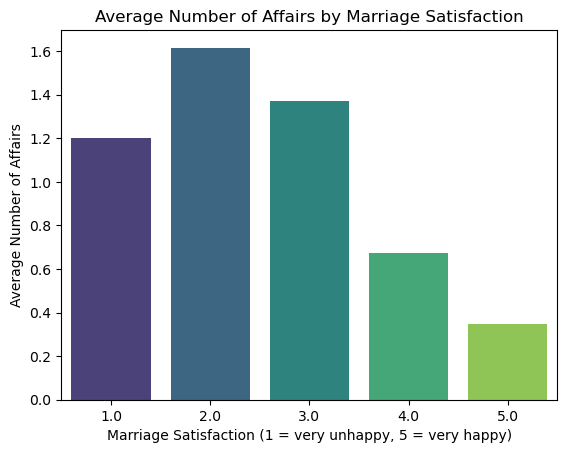

```python
# Plot to see Extra martial hours against Marriage satisfaction

# Find avg affairs per marriage rating
affairs_by_marriage = affairs.groupby('rate_marriage')['affairs'].mean().reset_index()

# Bar plot
sns.barplot(data=affairs_by_marriage, x='rate_marriage', y='affairs', palette='viridis')
plt.title("Average Number of Affairs by Marriage Satisfaction")
plt.xlabel("Marriage Satisfaction (1 = very unhappy, 5 = very happy)")
plt.ylabel("Average Number of Affairs")
plt.show()

# Affair rates drop sharply as marriage satisfaction increases.
```

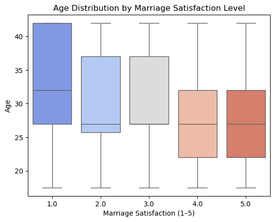

```python
# Age distribution by Marriage satisfaction
sns.boxplot(data=affairs, x='rate_marriage', y='age', palette='coolwarm')
plt.title("Age Distribution by Marriage Satisfaction Level")
plt.xlabel("Marriage Satisfaction (1–5)")
plt.ylabel("Age")
plt.show()
```

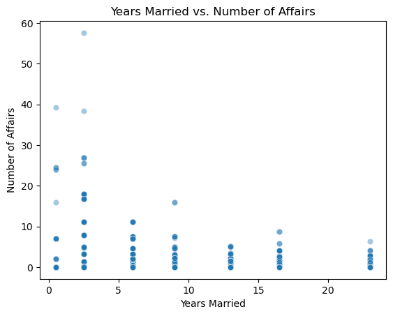

```python
# scatterplot:Years Married Vs Affairs
sns.scatterplot(data=affairs, x='yrs_married', y='affairs', alpha=0.4)
plt.title("Years Married vs. Number of Affairs")
plt.xlabel("Years Married")
plt.ylabel("Number of Affairs")
plt.show()
```

## People married for a very long time like 20 more years show few affairs (less than 10). People young into marriage generally show high hours in affairs.

## Ethical and Privacy concerns:

> The dataset contains highly sensitive personal information like marriage satisfaction, infidelity, religious beliefs. There is no clear indication if participants agreed to the their data being distributed publicly or researced on a large scale basis which can be a violation. With the given attributes in the dataset, it can be possible to track down individuals in a small town which is against re-identification norms. The data can potentially bring stereotype thinking and hamper moral judgement of certain people initiating bias.

(b) Suppose we want to explore the characteristics of participants who engage in extramarital sexual intercourse (i.e. affairs). Instead of modeling the number of affairs, consider the binary outcome - had an affair versus didn't have an affair. Create a new variable to capture this response variable of interest. What might the advantages and disadvantages of this approach to modeling the data be in this context?

```python
# Creating a variable 'yes_affair' which will hold binary value 1 if integer value of affairs column value is more than 1
# Reference --https://coderivers.org/blog/define-binary-variable-in-python/

affairs['yes_affair'] = (affairs['affairs'] > 0).astype(int) # The new variable will be 1 if affairs value is not 0.

affairs['yes_affair'].value_counts()
```

```
yes_affair
0    4313
1    2053
Name: count, dtype: int64
```

## So, 4313 people had no affair so value of yes_affair is 0 for them. Rest had atleast one affair. So variable value is 1 for them. The advantage of having this variable is that it will help to find out the probablity of a person having an affair. This will likely help to understand better why people have affair or just reduce skew and model with logistic regression.The disadvanatge is removes the concept of knowing the number of times a person had affair and almost making the fact that a person having affair once is same as the person having affair multiple times.There can be potential loss of information.

(c) Use an appropriate regression model to explore the relationship between having an affair (binary) and other personal characteristics. Comment on which covariates seem to be predictive of having an affair and which do not.

```python
# Referencing from -IMT_573_ps8_prediction-1_Bidyut.ipynb file
# https://www.geeksforgeeks.org/machine-learning/ml-logistic-regression-using-python/

# Prepare x(predictors) and y(target)
X = affairs [['rate_marriage', 'age', 'yrs_married', 'children', 'religious', 'educ', 'occupation', 'occupation_husb']]
X = sm.add_constant(X) # add intercept
y = affairs['yes_affair']
```

```python
# Fit Logistic regression model
simple_model = sm.Logit(y,X)

model = simple_model.fit()
```

```
Optimization terminated successfully.
         Current function value: 0.545314
         Iterations 6
```

```python
print(model.summary())
```

```
                           Logit Regression Results
==============================================================================
Dep. Variable:             yes_affair   No. Observations:                 6366
Model:                          Logit   Df Residuals:                     6357
Method:                           MLE   Df Model:                            8
Date:                Mon, 01 Dec 2025   Pseudo R-squ.:                  0.1327
Time:                        07:57:48   Log-Likelihood:                -3471.5
converged:                       True   LL-Null:                       -4002.5
Covariance Type:            nonrobust   LLR p-value:                5.807e-224
===================================================================================
                      coef    std err          z      P>|z|      [0.025      0.975]
-----------------------------------------------------------------------------------
const               3.7257      0.299     12.470      0.000       3.140       4.311
rate_marriage      -0.7161      0.031    -22.784      0.000      -0.778      -0.655
age                -0.0605      0.010     -5.885      0.000      -0.081      -0.040
yrs_married         0.1100      0.011     10.054      0.000       0.089       0.131
children           -0.0042      0.032     -0.134      0.893      -0.066       0.058
religious          -0.3752      0.035    -10.792      0.000      -0.443      -0.307
educ               -0.0392      0.015     -2.533      0.011      -0.070      -0.009
occupation          0.1602      0.034      4.717      0.000       0.094       0.227
occupation_husb     0.0124      0.023      0.541      0.589      -0.033       0.057
===================================================================================
```

(d) Use a model selection procedure to obtain a "best" fit model. Is the model different from the full model you fit in part (c)? Which variables are included in the "best" fit model? [Hint: stepwise selection]

## Model Selection Procedure

# Reference -- https://www.statology.org/stepwise-selection/

# reference-- https://uw.hosted.panopto.com/Panopto/Pages/Viewer.aspx?id=9884004c-b749-4923-bdfc-b217000c37e3&start=1270.1

---https://medium.com/@kelvinsang97/feature-selection-stepwise-regression-forward-selection-and-backward-elimination-with-python-d53230be995c

# We will implement here a Stepwise logistic selection which selects the best subset of predictors using model fit criteria.

```python
# reference (OpenAI, 2025)
def stepwise_selection(X, y,
                       initial_list=[],
                       threshold_in=0.01,
                       threshold_out=0.05,
                       verbose=True):

    included = list(initial_list)
    while True:
        changed=False

        # forward step
        excluded = list(set(X.columns) - set(included))
        new_pvals = pd.Series(index=excluded, dtype=float)
        for col in excluded:
            model = sm.Logit(y, sm.add_constant(pd.DataFrame(X[included + [col]]))).fit(disp=0)
            new_pvals[col] = model.pvalues[col]
        best_pval = new_pvals.min() if len(new_pvals)>0 else None

        if best_pval is not None and best_pval < threshold_in:
            best_feature = new_pvals.idxmin()
            included.append(best_feature)
            changed=True
            if verbose:
                print("Add  {:20} with p-value {:.4f}".format(best_feature, best_pval))

        # backward step
        model = sm.Logit(y, sm.add_constant(pd.DataFrame(X[included]))).fit(disp=0)
        pvals = model.pvalues.iloc[1:]
        worst_pval = pvals.max()

        if worst_pval > threshold_out:
            worst_feature = pvals.idxmax()
            included.remove(worst_feature)
            changed=True
            if verbose:
                print("Drop {:20} with p-value {:.4f}".format(worst_feature, worst_pval))

        if not changed:
            break

    return included
```

```python
X = affairs [['rate_marriage', 'age', 'yrs_married', 'children', 'religious', 'educ', 'occupation', 'occupation_husb']]
y = affairs['yes_affair']

best_vars = stepwise_selection(X, y)
print("\nBest model variables:", best_vars)
```

```
Add  rate_marriage        with p-value 0.0000
Add  yrs_married          with p-value 0.0000
Add  religious            with p-value 0.0000
Add  age                  with p-value 0.0000
Add  occupation           with p-value 0.0000

Best model variables: ['rate_marriage', 'yrs_married', 'religious', 'age', 'occupation']
```

## The step wise model is different from full model since stepwise best model has only 5 predictors against 8 predictors of full-model.

The variables included in best fit model are rate_marriage,yrs_married, religious, age and occupation.Stepwise selection removed three variables from the full model: children, educ, and occupation_husb. Therefore, the best model is smaller and more parsimonious than the full model while still capturing all meaningful predictors of yes_affair.

# Add constant

# Choose columns by name

(e) Interpret the model parameters using the model from part (d).

- rate_marriage: Effect: Negative Interpretation: As marital satisfaction increases, the likelihood of having an affair decreases sharply.

Odds ratio explanation: If the coefficient was about –0.72 (from the earlier logit model):A one-unit increase in rate_marriage (e.g., going from 3 to 4 on the satisfaction scale) cuts the odds of an affair in half.This is the strongest protective factor in the model.

- yrs_married :Effect: Positive Interpretation: The longer a person has been married, the more likely they are to have an affair.

Odds ratio: If the coefficient was ~0.11:Each additional year of marriage increases the odds of an affair by 12%.It’s a moderate but meaningful risk factor.

- religious:Effect: Strong negative Interpretation: More religious individuals are less likely to have an affair.

Odds ratio: If the coefficient was –0.375:For each increase in religiousness (e.g., from "rarely attends" → "often attends"), the odds of cheating decrease by about 31%.Religion is another strong protective factor.

- age:Effect: Negative Interpretation: Older individuals are less likely to have an affair. Odds ratio: With coefficient around –0.06:Each additional year of age reduces the odds of an affair by about 6%.Age has a small but consistent protective effect.
- occupation:Effect: Positive Interpretation: Some occupations are associated with a higher likelihood of having an affair.

(f) Create an artificial test dataset where martial rating varies from 1 to 5 randomly and all other variables are set to their means. Use this artificial dataset as your test dataset to obtain predicted probabilities of having an affair for case in the test data. Interpret your results and use a visualization to support your interpretation.

```python
# Variables in your final stepwise model
best_vars = ['rate_marriage','age','yrs_married','religious','occupation']


X = affairs[best_vars]
X = sm.add_constant(X)
y = affairs['yes_affair']

# Fit logistic regression
best_model = sm.Logit(y, X).fit()
best_model.summary()
```

```
Optimization terminated successfully.
         Current function value: 0.545825
         Iterations 6
```

Logit Regression Results

| Dep. Variable: | yes_affair | No. Observations: | 6366 |
| --- | --- | --- | --- |
| Model: | Logit | Df Residuals: | 6360 |
| Method: | MLE | Df Model: | 5 |
| Date: | Mon, 01 Dec 2025 | Pseudo R-squ.: | 0.1319 |
| Time: | 07:58:40 | Log-Likelihood: | -3474.7 |
| converged: | True | LL-Null: | -4002.5 |
| Covariance Type: | nonrobust | LLR p-value: | 5.463e-226 |

|  | coef | std err | z | P>\|z\| | [0.025 | 0.975] |
| --- | --- | --- | --- | --- | --- | --- |
| const | 3.4353 | 0.269 | 12.774 | 0.000 | 2.908 | 3.962 |
| rate_marriage | -0.7185 | 0.031 | -22.924 | 0.000 | -0.780 | -0.657 |
| age | -0.0663 | 0.010 | -6.641 | 0.000 | -0.086 | -0.047 |
| yrs_married | 0.1160 | 0.009 | 12.324 | 0.000 | 0.098 | 0.134 |
| religious | -0.3770 | 0.035 | -10.901 | 0.000 | -0.445 | -0.309 |
| occupation | 0.1331 | 0.031 | 4.235 | 0.000 | 0.071 | 0.195 |

```python
# Artificial test dataset

test_df = pd.DataFrame({
    'rate_marriage': np.arange(1, 6),   # values 1,2,3,4,5
    'age': [affairs['age'].mean()] * 5,
    'yrs_married': [affairs['yrs_married'].mean()] * 5,
    'religious': [affairs['religious'].mean()] * 5,
    'educ': [affairs['educ'].mean()] * 5,
    'occupation': [affairs['occupation'].mean()] * 5
})

# Add constant for prediction
test_df = sm.add_constant(test_df)

test_df
```

|  | rate_marriage | age | yrs_married | religious | educ | occupation |
| --- | --- | --- | --- | --- | --- | --- |
| 0 | 1 | 29.082862 | 9.009425 | 2.42617 | 14.209865 | 3.424128 |
| 1 | 2 | 29.082862 | 9.009425 | 2.42617 | 14.209865 | 3.424128 |
| 2 | 3 | 29.082862 | 9.009425 | 2.42617 | 14.209865 | 3.424128 |
| 3 | 4 | 29.082862 | 9.009425 | 2.42617 | 14.209865 | 3.424128 |
| 4 | 5 | 29.082862 | 9.009425 | 2.42617 | 14.209865 | 3.424128 |

```python
# Predict probabilities
test_df['predicted_prob'] = best_model.predict(test_df)
test_df
```

|  | rate_marriage | age | yrs_married | religious | educ | occupation | predicted_prob |
| --- | --- | --- | --- | --- | --- | --- | --- |
| 0 | 1 | 29.082862 | 9.009425 | 2.42617 | 14.209865 | 3.424128 | 1.414376e-10 |
| 1 | 2 | 29.082862 | 9.009425 | 2.42617 | 14.209865 | 3.424128 | 4.390498e-09 |
| 2 | 3 | 29.082862 | 9.009425 | 2.42617 | 14.209865 | 3.424128 | 1.362896e-07 |
| 3 | 4 | 29.082862 | 9.009425 | 2.42617 | 14.209865 | 3.424128 | 4.230679e-06 |
| 4 | 5 | 29.082862 | 9.009425 | 2.42617 | 14.209865 | 3.424128 | 1.313118e-04 |

```python
print(test_df[['rate_marriage', 'predicted_prob']]) # Print the predicted probabilities numerically
```

```
   rate_marriage  predicted_prob
0              1    1.414376e-10
1              2    4.390498e-09
2              3    1.362896e-07
3              4    4.230679e-06
4              5    1.313118e-04
```

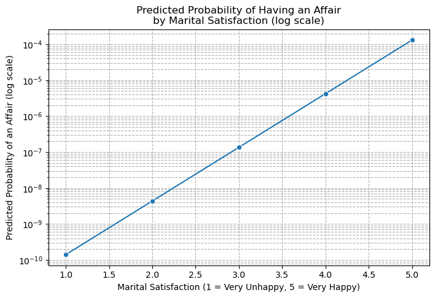

```python
import matplotlib.pyplot as plt
import seaborn as sns

plt.figure(figsize=(8,5))
sns.lineplot(data=test_df, x='rate_marriage', y='predicted_prob', marker='o')
plt.yscale('log')  # log scale to stretch small values
plt.title("Predicted Probability of Having an Affair\nby Marital Satisfaction (log scale)")
plt.xlabel("Marital Satisfaction (1 = Very Unhappy, 5 = Very Happy)")
plt.ylabel("Predicted Probability of an Affair (log scale)")
plt.grid(True, which="both", ls="--")
plt.show()
```

## The predicted probabilities increase exponentially as marital satisfaction goes from 1 to 5 — because the y-axis is on a log scale, and the points lie on a straight line, indicating exponential growth in probabilities.However, these probabilities are extremely small in absolute terms.This is counterintuitive, because the model's theory and coefficients say higher marital satisfaction should decrease the probability of an affair, not increase it.

(g) Reflect on your analysis in this problem. After completing all the parts of this analysis what remaining and additional ethical and privacy conerns do you have?

- Sensitivity and confidentiality: The dataset involves highly personal and potentially stigmatizing information about individuals’ marital fidelity, religion, age, occupation, etc. Misuse or careless handling can lead to harm or discrimination.Even if data is anonymized, certain combinations of features (e.g., occupation + age + years married) might indirectly identify individuals, especially in small subgroups.
- Informed Consent :It’s critical that participants gave informed consent for their data to be collected and analyzed, especially for sensitive topics.Participants should have been clearly informed about how their data will be used, stored, and who will have access.
- Data Security and Storage :Sensitive data must be stored securely, encrypted, and access-controlled.
- Model Transparency and Fairness :It’s essential to communicate clearly that predictions are probabilistic and not deterministic — they can never “prove” who will have an affair. The model may be biased due to sample selection or missing variables; care must be taken to avoid overgeneralization.

### Problem 2

Points: 20

In this problem set, we will use some data from a sports context. The data is provided as part of the [Introduction to Statistial Learning with Applications in Python](https://www.statlearning.com/) textbook. It was taken from the StatLib library which is maintained at Carnegie Mellon University. The data provided is part of the data that was used in the 1988 ASA Graphics Section Poster Session. The salary data were originally from Sports Illustrated, April 20, 1987. The 1986 and career statistics were obtained from The 1987 Baseball Encyclopedia Update published by Collier Books, Macmillan Publishing Company, New York.

Following the directions below to load this data, `Hitters` directly from the `ISLP` python package. You may need to install the `ISLP` package before you can get started. In the Jupyter Hub you can open a terminal and use `pip install ISLP`. Next load the data as follows:

```python
!pip install ISLP
```

[output not shown]

```python
from ISLP import load_data
Hitters = load_data('Hitters')

###Hitters.head()
```

```python
Hitters.head() # look at first few rows
```

|  | AtBat | Hits | HmRun | Runs | RBI | Walks | Years | CAtBat | CHits | CHmRun | CRuns | CRBI | CWalks | League | Division | PutOuts | Assists | Errors | Salary | NewLeague |
| --- | --- | --- | --- | --- | --- | --- | --- | --- | --- | --- | --- | --- | --- | --- | --- | --- | --- | --- | --- | --- |
| 0 | 293 | 66 | 1 | 30 | 29 | 14 | 1 | 293 | 66 | 1 | 30 | 29 | 14 | A | E | 446 | 33 | 20 | NaN | A |
| 1 | 315 | 81 | 7 | 24 | 38 | 39 | 14 | 3449 | 835 | 69 | 321 | 414 | 375 | N | W | 632 | 43 | 10 | 475.0 | N |
| 2 | 479 | 130 | 18 | 66 | 72 | 76 | 3 | 1624 | 457 | 63 | 224 | 266 | 263 | A | W | 880 | 82 | 14 | 480.0 | A |
| 3 | 496 | 141 | 20 | 65 | 78 | 37 | 11 | 5628 | 1575 | 225 | 828 | 838 | 354 | N | E | 200 | 11 | 3 | 500.0 | N |
| 4 | 321 | 87 | 10 | 39 | 42 | 30 | 2 | 396 | 101 | 12 | 48 | 46 | 33 | N | E | 805 | 40 | 4 | 91.5 | N |

```python
# check basic information of variables and missing values if any
Hitters.info()
```

```
<class 'pandas.core.frame.DataFrame'>
RangeIndex: 322 entries, 0 to 321
Data columns (total 20 columns):
 #   Column     Non-Null Count  Dtype
---  ------     --------------  -----
 0   AtBat      322 non-null    int64
 1   Hits       322 non-null    int64
 2   HmRun      322 non-null    int64
 3   Runs       322 non-null    int64
 4   RBI        322 non-null    int64
 5   Walks      322 non-null    int64
 6   Years      322 non-null    int64
 7   CAtBat     322 non-null    int64
 8   CHits      322 non-null    int64
 9   CHmRun     322 non-null    int64
 10  CRuns      322 non-null    int64
 11  CRBI       322 non-null    int64
 12  CWalks     322 non-null    int64
 13  League     322 non-null    category
 14  Division   322 non-null    category
 15  PutOuts    322 non-null    int64
 16  Assists    322 non-null    int64
 17  Errors     322 non-null    int64
 18  Salary     263 non-null    float64
 19  NewLeague  322 non-null    category
dtypes: category(3), float64(1), int64(16)
memory usage: 44.2 KB
```

```python
# Summary statistics
Hitters.describe()
```

|  | AtBat | Hits | HmRun | Runs | RBI | Walks | Years | CAtBat | CHits | CHmRun | CRuns | CRBI | CWalks | PutOuts | Assists | Errors | Salary |
| --- | --- | --- | --- | --- | --- | --- | --- | --- | --- | --- | --- | --- | --- | --- | --- | --- | --- |
| count | 322.000000 | 322.000000 | 322.000000 | 322.000000 | 322.000000 | 322.000000 | 322.000000 | 322.00000 | 322.000000 | 322.000000 | 322.000000 | 322.000000 | 322.000000 | 322.000000 | 322.000000 | 322.000000 | 263.000000 |
| mean | 380.928571 | 101.024845 | 10.770186 | 50.909938 | 48.027950 | 38.742236 | 7.444099 | 2648.68323 | 717.571429 | 69.490683 | 358.795031 | 330.118012 | 260.239130 | 288.937888 | 106.913043 | 8.040373 | 535.925882 |
| std | 153.404981 | 46.454741 | 8.709037 | 26.024095 | 26.166895 | 21.639327 | 4.926087 | 2324.20587 | 654.472627 | 86.266061 | 334.105886 | 333.219617 | 267.058085 | 280.704614 | 136.854876 | 6.368359 | 451.118681 |
| min | 16.000000 | 1.000000 | 0.000000 | 0.000000 | 0.000000 | 0.000000 | 1.000000 | 19.00000 | 4.000000 | 0.000000 | 1.000000 | 0.000000 | 0.000000 | 0.000000 | 0.000000 | 0.000000 | 67.500000 |
| 25% | 255.250000 | 64.000000 | 4.000000 | 30.250000 | 28.000000 | 22.000000 | 4.000000 | 816.75000 | 209.000000 | 14.000000 | 100.250000 | 88.750000 | 67.250000 | 109.250000 | 7.000000 | 3.000000 | 190.000000 |
| 50% | 379.500000 | 96.000000 | 8.000000 | 48.000000 | 44.000000 | 35.000000 | 6.000000 | 1928.00000 | 508.000000 | 37.500000 | 247.000000 | 220.500000 | 170.500000 | 212.000000 | 39.500000 | 6.000000 | 425.000000 |
| 75% | 512.000000 | 137.000000 | 16.000000 | 69.000000 | 64.750000 | 53.000000 | 11.000000 | 3924.25000 | 1059.250000 | 90.000000 | 526.250000 | 426.250000 | 339.250000 | 325.000000 | 166.000000 | 11.000000 | 750.000000 |
| max | 687.000000 | 238.000000 | 40.000000 | 130.000000 | 121.000000 | 105.000000 | 24.000000 | 14053.00000 | 4256.000000 | 548.000000 | 2165.000000 | 1659.000000 | 1566.000000 | 1378.000000 | 492.000000 | 32.000000 | 2460.000000 |

```python
# Count missing values
Hitters.isna().sum()
```

```
AtBat         0
Hits          0
HmRun         0
Runs          0
RBI           0
Walks         0
Years         0
CAtBat        0
CHits         0
CHmRun        0
CRuns         0
CRBI          0
CWalks        0
League        0
Division      0
PutOuts       0
Assists       0
Errors        0
Salary       59
NewLeague     0
dtype: int64
```

```python
# Reference of code from IMT_573_ps8_prediction-1_Bidyut.ipynb
# Get unique values for categorical variables
categorical_columns = ['League', 'Division', 'NewLeague']
for col in categorical_columns:
    print(f"{col}: {sorted(Hitters[col].unique())}")
    print()
    print()
```

```
League: ['A', 'N']


Division: ['E', 'W']


NewLeague: ['A', 'N']
```

```python
# Finding the counts with the above values of categorical variables
Hitters["League"].value_counts()
```

```
League
A    175
N    147
Name: count, dtype: int64
```

```python
Hitters["Division"].value_counts()
```

```
Division
W    165
E    157
Name: count, dtype: int64
```

```python
Hitters["NewLeague"].value_counts()
```

```
NewLeague
A    176
N    146
Name: count, dtype: int64
```

```python
# Finding the max and min value of Salary
Hitters['Salary'].max()
```

```
2460.0
```

```python
Hitters['Salary'].min()
```

```
67.5
```

```python
print(" Shape")
print(Hitters.shape)

print("Types")
print(Hitters.dtypes)

print("Tail")
print(Hitters.tail)
```

[output not shown]

[output cut: 10 more lines]

[output not shown]

(a) Develop your own question to address in this analysis. Your question should be specific and measurable, and it should be able to be addressed through a basic analysis of the `Hitters` dataset. Hint: you will need to get to know this dataset and the variables available to formulate an appropriate question.

## Question : Do players with more career hits (CHits) tend to earn higher salaries?

# Reference read--https://www.kaggle.com/datasets/floser/hitters

The predictor variable will be CHits (Career Hits) and outcome variable (Salary). Salary tends to be a measure of player's value in a league.CHits means long-term performance of the player. Missing values of Salary needs to be removed for analysis. This is possible to measure it using a scatterplot of CHits Vs. salary

```python
# Clean the data to remove missing Salary values
Salary_remove = Hitters.dropna(subset=['Salary'])
Salary_remove.head()
```

|  | AtBat | Hits | HmRun | Runs | RBI | Walks | Years | CAtBat | CHits | CHmRun | CRuns | CRBI | CWalks | League | Division | PutOuts | Assists | Errors | Salary | NewLeague |
| --- | --- | --- | --- | --- | --- | --- | --- | --- | --- | --- | --- | --- | --- | --- | --- | --- | --- | --- | --- | --- |
| 1 | 315 | 81 | 7 | 24 | 38 | 39 | 14 | 3449 | 835 | 69 | 321 | 414 | 375 | N | W | 632 | 43 | 10 | 475.0 | N |
| 2 | 479 | 130 | 18 | 66 | 72 | 76 | 3 | 1624 | 457 | 63 | 224 | 266 | 263 | A | W | 880 | 82 | 14 | 480.0 | A |
| 3 | 496 | 141 | 20 | 65 | 78 | 37 | 11 | 5628 | 1575 | 225 | 828 | 838 | 354 | N | E | 200 | 11 | 3 | 500.0 | N |
| 4 | 321 | 87 | 10 | 39 | 42 | 30 | 2 | 396 | 101 | 12 | 48 | 46 | 33 | N | E | 805 | 40 | 4 | 91.5 | N |
| 5 | 594 | 169 | 4 | 74 | 51 | 35 | 11 | 4408 | 1133 | 19 | 501 | 336 | 194 | A | W | 282 | 421 | 25 | 750.0 | A |

```python
# Summary statistics
Salary_remove[['CHits','Salary']].describe()
```

|  | CHits | Salary |
| --- | --- | --- |
| count | 263.000000 | 263.000000 |
| mean | 722.186312 | 535.925882 |
| std | 648.199644 | 451.118681 |
| min | 4.000000 | 67.500000 |
| 25% | 212.000000 | 190.000000 |
| 50% | 516.000000 | 425.000000 |
| 75% | 1054.000000 | 750.000000 |
| max | 4256.000000 | 2460.000000 |

```python
#Checking coorrelation
Salary_remove[['CHits','Salary']].corr()
```

|  | CHits | Salary |
| --- | --- | --- |
| CHits | 1.00000 | 0.54891 |
| Salary | 0.54891 | 1.00000 |

## The coorelation between Chits and Salary is 0.54891 which is a moderate positive correlation.As a player's career hits increase, their salary also tends to increase.But Salary is also influenced by other factors like homeruns, experiences.

# reference --https://www.geeksforgeeks.org/data-analysis/exploring-correlation-in-python/

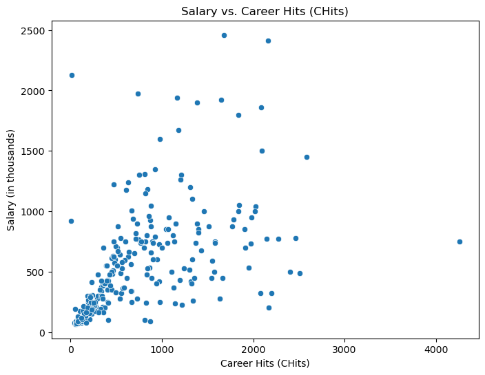

```python
# Scatterplot
plt.figure(figsize=(8,6))
sns.scatterplot(x='CHits', y='Salary', data=Salary_remove)
plt.title("Salary vs. Career Hits (CHits)")
plt.xlabel("Career Hits (CHits)")
plt.ylabel("Salary (in thousands)")
plt.show()
```

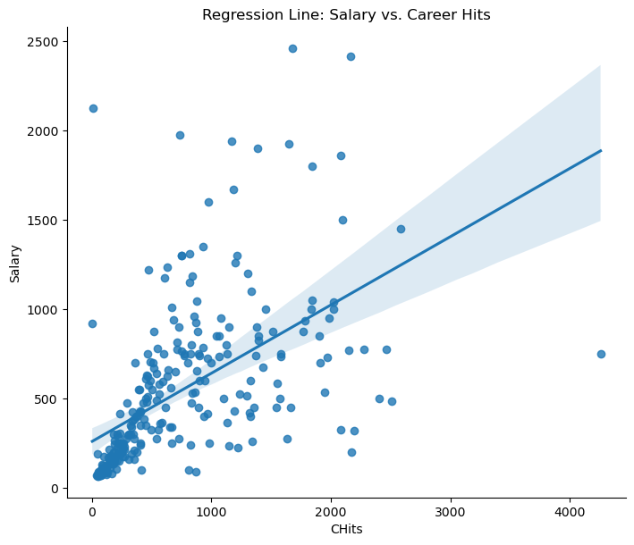

```python
# Adding regression line
sns.lmplot(x='CHits', y='Salary', data=Salary_remove, height=6, aspect=1.2)
plt.title("Regression Line: Salary vs. Career Hits")
plt.show()
```

```python
# This gives a clear visual showing whether salary increases with career hits.Since the variables are correlated, we can do the regression step to quantify the relationship.
```

```python
# regression

X = Salary_remove[['CHits']]
X = sm.add_constant(X)   # adds intercept
y = Salary_remove['Salary']

model = sm.OLS(y, X).fit()
print(model.summary())
```

```
                            OLS Regression Results
==============================================================================
Dep. Variable:                 Salary   R-squared:                       0.301
Model:                            OLS   Adj. R-squared:                  0.299
Method:                 Least Squares   F-statistic:                     112.6
Date:                Mon, 01 Dec 2025   Prob (F-statistic):           4.26e-22
Time:                        07:59:11   Log-Likelihood:                -1932.9
No. Observations:                 263   AIC:                             3870.
Df Residuals:                     261   BIC:                             3877.
Df Model:                           1
Covariance Type:            nonrobust
==============================================================================
                 coef    std err          t      P>|t|      [0.025      0.975]
------------------------------------------------------------------------------
const        260.0384     34.914      7.448      0.000     191.290     328.787
CHits          0.3820      0.036     10.609      0.000       0.311       0.453
==============================================================================
Omnibus:                       96.495   Durbin-Watson:                   2.022
Prob(Omnibus):                  0.000   Jarque-Bera (JB):              341.177
Skew:                           1.548   Prob(JB):                     8.21e-75
Kurtosis:                       7.643   Cond. No.                     1.45e+03
==============================================================================

Notes:
[1] Standard Errors assume that the covariance matrix of the errors is correctly specified.
[2] The condition number is large, 1.45e+03. This might indicate that there are
strong multicollinearity or other numerical problems.
```

## The regression equation Salary = 260.04 + o.382 * CHits

Intercept (260.04) means the expected salary for a player with zero career hits. Slope (0.382) means for each career hit, a player's salary increases by about $382( Assuming salary measured in dollars). This indicates a positive relation as in the correlation. The |t| value for CHits is 10.609 and p-value is 0.000 (less than 0.05). This show CHits is a significant predictor of salary and there is strong statiscal evidence that players with more career hits get higher salaries. R-squared is 0.301 meaning about 30% of variation in player salary is impacted by Career hits alone.

(b) Briefly summarize the dataset, describing what data exists and its basic properties. Comment on any issues that need to be resolved before you can proceed with your analysis.

## The Hitters dataset contains information on Major League Baseball players, including their performance statistics from the 1986 season, cumulative career performance, and salary data. The dataset includes 322 observations (players) and 20 variables covering batting performance, fielding performance, player experience, league affiliation, and salary.

Types of Variables in the Dataset Season performance variables (1986): AtBat, Hits, HmRun, Runs, RBI, Walks These measure how a player performed during the 1986 season.

Career performance variables: CAtBat, CHits, CHmRun, CRuns, CRBI, CWalks These summarize a player’s cumulative career achievements up to 1986.

Experience and position-related variables: Years (years in the MLB), PutOuts, Assists, Errors

Categorical variables: League, Division, NewLeague These indicate the league (American or National) and division.

Salary variable: Salary — player’s 1987 salary in thousands of dollars.

Issues- There are 59 salary values which have no data. Since Salary is primary outcome like in abaove anaylsis, rows with missing salary values must be removed before making analysis.

(c) Use the dataset to provide empirical evidence that addressed your question from (a). Discuss your results. Provide at least two visualizations to support your story.

## As done in step a), the evidence to support the answer to the question is Correlation evidence. The correlation between Chits and Salary is r= 0.5489.This indicates a positive moderate relationship. Players with more career hits tend to have higher salaries.

## The evidence from regression equation Salary = 260.04 + o.382 * CHits says, CHits coefficient is highly statistically significant(p <0.001). For each additional career hit, salary increase by $382. Hence this is strong statistical evidence for player with more career hits earn higher salaries.

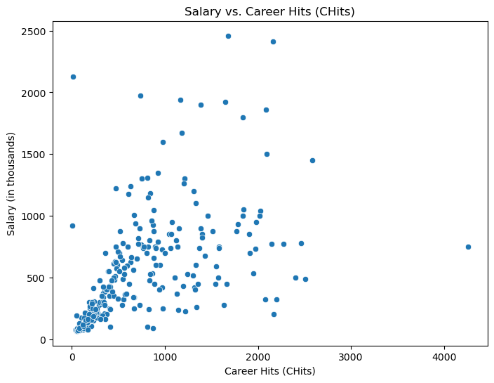

```python
# Visualizations
# Scatterplot os Salary Vs CareerHits as done in a)
plt.figure(figsize=(8,6))
sns.scatterplot(x='CHits', y='Salary', data=Salary_remove)
plt.title("Salary vs. Career Hits (CHits)")
plt.xlabel("Career Hits (CHits)")
plt.ylabel("Salary (in thousands)")
plt.show()
```

```python
# The plot shows a clear upward trend. The points are spread , but the positive pattern is visible showing with more career hits, players get more salary.
```

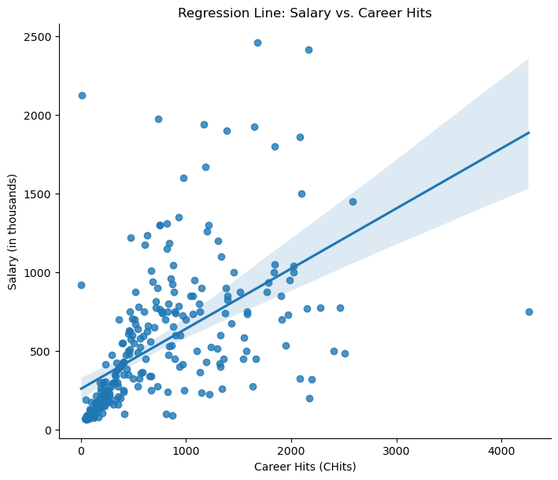

```python
# regression as done in a)
sns.lmplot(x='CHits', y='Salary', data=Salary_remove, height=6, aspect=1.2)
plt.title("Regression Line: Salary vs. Career Hits")
plt.xlabel("Career Hits (CHits)")
plt.ylabel("Salary (in thousands)")
plt.show()
print()
print()
```

```python
# The regression line highlights the positive linear relationship.The slope is positive, confirming that salary increases as CHits increases.
```

(d) Comment the questions (and answers) in this analysis. Were you able to answer all of these questions? Are all questions well defined? Is the data good enough to answer all these?

## The question was well-defined in the analysis and it was specific (named the variables), measurable (used quantitative data), and answerable using simple statistical tools.I was able to find the answer through correlation analysis, scatterplot and regression-line visualization, and simple linear regression model.

## Though the absence of few missing salary values reduced the sample size for the analysis, it was enough for finding a convincing anwer to the question. Salary is dependent on multiple factors and using only CHits explains 30% of variation in the salary. Hence the model answers the specific question but doesnot have all the details to do the holistic salary determination.

### Problem 3

Points: 20

In this problem, we will use data available in [Machine Learning with R by Brett Lantz](https://subscription.packtpub.com/search?query=machine%20learning%20r). This data was available in the public domain and a few version exist online.

The data describe individual medical costs billed by health insurance. For each observation, there is information about:

- age: age of primary beneficiary of the insurance policy
- sex: the person's sex, measured here a binary gender
- bmi: body mass index, providing an understanding of body, weights that are relatively high or low relative to height, (kg / m ^ 2)
- children: number of children/dependents covered by health insurance
- smoker: smoking status of the primary beneficiary
- region: the beneficiary's residential area in the US, northeast, southeast, southwest, northwest.
- charges: medical costs billed by health insurance

In our analysis, we will be interested in the relationship between `charges` and the individual characteristics measured.

```python
df = pd.read_csv('insurance.csv')
# df.head()
```

```python
df.head()
```

|  | age | sex | bmi | children | smoker | region | charges |
| --- | --- | --- | --- | --- | --- | --- | --- |
| 0 | 19 | female | 27.900 | 0 | yes | southwest | 16884.92400 |
| 1 | 18 | male | 33.770 | 1 | no | southeast | 1725.55230 |
| 2 | 28 | male | 33.000 | 3 | no | southeast | 4449.46200 |
| 3 | 33 | male | 22.705 | 0 | no | northwest | 21984.47061 |
| 4 | 32 | male | 28.880 | 0 | no | northwest | 3866.85520 |

```python
df.info()
```

```
<class 'pandas.core.frame.DataFrame'>
RangeIndex: 1338 entries, 0 to 1337
Data columns (total 7 columns):
 #   Column    Non-Null Count  Dtype
---  ------    --------------  -----
 0   age       1338 non-null   int64
 1   sex       1338 non-null   object
 2   bmi       1338 non-null   float64
 3   children  1338 non-null   int64
 4   smoker    1338 non-null   object
 5   region    1338 non-null   object
 6   charges   1338 non-null   float64
dtypes: float64(2), int64(2), object(3)
memory usage: 73.3+ KB
```

```python
df['sex'].unique()
```

```
array(['female', 'male'], dtype=object)
```

```python
df['region'].unique()
```

```
array(['southwest', 'southeast', 'northwest', 'northeast'], dtype=object)
```

```python
df['age'].unique()
```

```
array([19, 18, 28, 33, 32, 31, 46, 37, 60, 25, 62, 23, 56, 27, 52, 30, 34,
       59, 63, 55, 22, 26, 35, 24, 41, 38, 36, 21, 48, 40, 58, 53, 43, 64,
       20, 61, 44, 57, 29, 45, 54, 49, 47, 51, 42, 50, 39])
```

```python
# find the region wise max ,min , mean charge and count for each sex

grouped = df.groupby(['region', 'sex'])['charges'].agg(['min', 'max', 'mean', 'count'])
print (grouped)
```

```
                         min          max          mean  count
region    sex
northeast female  2196.47320  58571.07448  12953.203151    161
          male    1694.79640  48549.17835  13854.005374    163
northwest female  2117.33885  55135.40209  12479.870397    164
          male    1621.34020  60021.39897  12354.119575    161
southeast female  1607.51010  63770.42801  13499.669243    175
          male    1121.87390  62592.87309  15879.617173    189
southwest female  1727.78500  48824.45000  11274.411264    162
          male    1241.56500  52590.82939  13412.883576    163
```

```python
# find the max charges of a person in each region including age, gender and dependents
grouped2 = df.loc[df.groupby('region')['charges'].idxmax(), ['age', 'sex', 'children', 'region', 'charges']]
print (grouped2)
```

```
      age     sex  children     region      charges
577    31  female         1  northeast  58571.07448
1230   52    male         3  northwest  60021.39897
543    54  female         0  southeast  63770.42801
1146   60    male         0  southwest  52590.82939
```

In our analysis, we will be interested in the relationship between charges and the individual characteristics measured.

(a) Examine the bivariate relationships present in the data. Briefly discuss notable results.

```python
# Reference --https://www.geeksforgeeks.org/maths/bivariate-analysis/
# Reference --https://medium.com/@tristenwallace/bivariate-data-exploration-with-matplotlib-seaborn-6ff43de5735a
```

```python
# checking the datatypes of the variables
df.dtypes
```

```
age           int64
sex          object
bmi         float64
children      int64
smoker       object
region       object
charges     float64
dtype: object
```

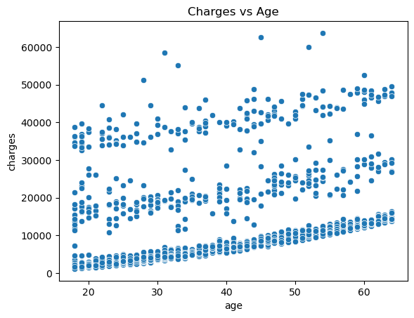

```python
# Numerical Vs Numerical analysis (Charges Vs Age) Scatterplot
sns.scatterplot(data=df, x='age', y='charges')
plt.title("Charges vs Age")
plt.show()
```

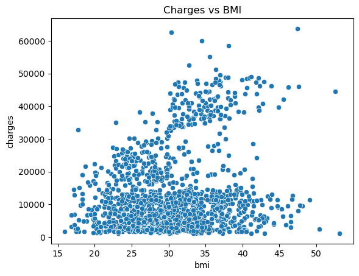

```python
# Numerical Vs Numerical analysis (Charges Vs BMI) Scatterplot
sns.scatterplot(data=df, x='bmi', y='charges')
plt.title("Charges vs BMI")
plt.show()
```

## There is no visible linear relation between charges and bmi and looks diffused pattern particularly for more bmi persons. There are noticeable clusters in 25-35 bmi index and 35-40 index suggesting people

with higher bmi might have higher medical expenses. Bmi alone shows a weak relation but a positive pattern with charges.

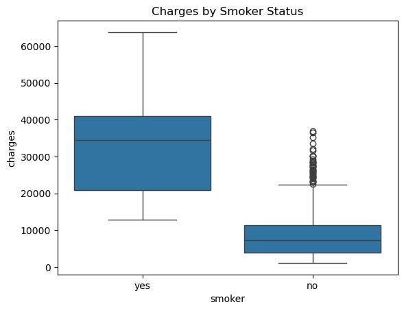

```python
# Categorical Vs Charges --Boxplot: Charges by Smoker
sns.boxplot(data=df, x='smoker', y='charges')
plt.title("Charges by Smoker Status")
plt.show()
```

## Smokers have a visible higher median charges (around $35,000) and wide range extending up to $60,000. Non-smokers have low median charges less than $10,000 with some outliers. The separation between the two

boxes is very large and there is no overlap in medians. Smoking hence has a strong impact on the medical charges incurred.

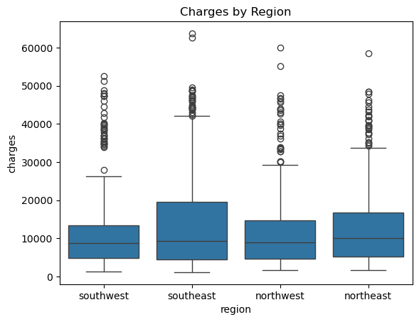

```python
# Categorical Vs Charges --Boxplot: Charges by Region
sns.boxplot(data=df, x='region', y='charges')
plt.title("Charges by Region")
plt.show()
```

## The four regions have the same median charges. The southeast region seems to have a wider range in charges followed by northeast region and northwest.

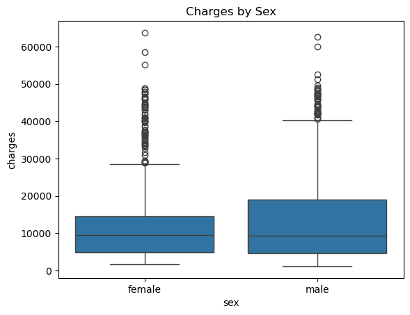

```python
# Categorical Vs Charges --Boxplot: Charges by Sex
sns.boxplot(data=df, x='sex', y='charges')
plt.title("Charges by Sex")
plt.show()
```

## Male persons have a wider range of charges than the female counterparts suggesting that they tend to have higher medical related expenses.

```python
# Coorelational
df[['age', 'bmi', 'children', 'charges']].corr()
```

|  | age | bmi | children | charges |
| --- | --- | --- | --- | --- |
| age | 1.000000 | 0.109272 | 0.042469 | 0.299008 |
| bmi | 0.109272 | 1.000000 | 0.012759 | 0.198341 |
| children | 0.042469 | 0.012759 | 1.000000 | 0.067998 |
| charges | 0.299008 | 0.198341 | 0.067998 | 1.000000 |

## Relation between age and charges --

Correlation is 0.30 which is moderate positive. That means as age increase, medical charges tend to increase or older inidividuals have higher health costs.Age seems the strongest predictor of charges.

## Relation between bmi and charges --

Correlation is 0.20 which is weak positive. That means people with higher BMI tend to have higher medical charges.Bmi alone explains a small portion of variation in charges.

## Relation between children number and charges--

Correlation is 0.07 which is very low positive. That means having more dependents might influence charges but not strongly. The effect is negligible.Children are not meaningful predictor of charges.

## Relation between other predictors like age and bmi, age and children , bmi and children--

The correlation is very low as seen in the table saying the negligble effect on each of other factors suggesting low multicollinearity.

(b) Fit a multiple linear regression model. How much variance in the medical costs(charges) does this variable- bmi explain?

## Multiple Linear Regression model written as Y = B0 + B1X1 + B2X2 + B3X3 + B4X4 + B5X5 + B6X6 + e

# where 1,2,..6 are predictors

# B1, B2, ... B6 are the parameters are estimated using the same least squares approach, using a computer.

# We interpret Bi as the average effect on Y per one-unit increase in X holding all other predictors fixed where i is the number of predictors.

# reference --https://canvas.uw.edu/courses/1830727/pages/7-dot-7-multiple-linear-regression?module_item_id=24478640

Here the regression equation would be charges = B0 + B1 * age + B2 * bmi + B3*children + B4*smoker + B5*sex + B6*region + e

```python
# First converting categorical variables to dummy variables to be used in regression
# Reference -- https://www.geeksforgeeks.org/machine-learning/how-to-handle-categorical-variables-in-regression/

df = pd.get_dummies(df, drop_first = True) # # drop_first to avoid multicollinearity
df['charges'] = pd.to_numeric(df['charges'], errors='coerce')

# Convert all bool columns to int
bool_cols = df.select_dtypes(include='bool').columns
df[bool_cols] = df[bool_cols].astype(int)
```

```python
df.dtypes
```

```
age                   int64
bmi                 float64
children              int64
charges             float64
sex_male              int64
smoker_yes            int64
region_northwest      int64
region_southeast      int64
region_southwest      int64
dtype: object
```

```python
X = df.drop("charges", axis=1)
y = df["charges"]
```

```python
# Referenced code from IMT_573_Lab7_regression.ipynb
X = sm.add_constant(X)
model = sm.OLS(y, X).fit()
print(model.summary())
```

```
                            OLS Regression Results
==============================================================================
Dep. Variable:                charges   R-squared:                       0.751
Model:                            OLS   Adj. R-squared:                  0.749
Method:                 Least Squares   F-statistic:                     500.8
Date:                Mon, 01 Dec 2025   Prob (F-statistic):               0.00
Time:                        07:59:44   Log-Likelihood:                -13548.
No. Observations:                1338   AIC:                         2.711e+04
Df Residuals:                    1329   BIC:                         2.716e+04
Df Model:                           8
Covariance Type:            nonrobust
====================================================================================
                       coef    std err          t      P>|t|      [0.025      0.975]
------------------------------------------------------------------------------------
const            -1.194e+04    987.819    -12.086      0.000   -1.39e+04      -1e+04
age                256.8564     11.899     21.587      0.000     233.514     280.199
bmi                339.1935     28.599     11.860      0.000     283.088     395.298
children           475.5005    137.804      3.451      0.001     205.163     745.838
sex_male          -131.3144    332.945     -0.394      0.693    -784.470     521.842
smoker_yes        2.385e+04    413.153     57.723      0.000     2.3e+04    2.47e+04
region_northwest  -352.9639    476.276     -0.741      0.459   -1287.298     581.370
region_southeast -1035.0220    478.692     -2.162      0.031   -1974.097     -95.947
region_southwest  -960.0510    477.933     -2.009      0.045   -1897.636     -22.466
==============================================================================
Omnibus:                      300.366   Durbin-Watson:                   2.088
Prob(Omnibus):                  0.000   Jarque-Bera (JB):              718.887
Skew:                           1.211   Prob(JB):                    7.86e-157
Kurtosis:                       5.651   Cond. No.                         311.
==============================================================================

Notes:
[1] Standard Errors assume that the covariance matrix of the errors is correctly specified.
```

## Interpretation of the results above

- age (coef = 256.86): Older people tend to have higher charges.
- bmi (coef = 339.19): Higher BMI increases charges.
- children (coef = 475.50): More children slightly increases charges.
- smoker_yes (coef = 23850): Smoking drastically increases medical costs.
- region_southeast and region_southwest: Slight negative effect compared to the baseline (region_northeast).

```python
# Linear model with only bmi as predictor to find variance
# https://www.lesahoffman.com/PSQF6242/PSQF6242_Lecture3_GLM_Single_Predictor.pdf

X_bmi = sm.add_constant(df["bmi"])
model_bmi = sm.OLS(df["charges"],X_bmi).fit()
print(model_bmi.summary())
```

```
                            OLS Regression Results
==============================================================================
Dep. Variable:                charges   R-squared:                       0.039
Model:                            OLS   Adj. R-squared:                  0.039
Method:                 Least Squares   F-statistic:                     54.71
Date:                Mon, 01 Dec 2025   Prob (F-statistic):           2.46e-13
Time:                        07:59:45   Log-Likelihood:                -14451.
No. Observations:                1338   AIC:                         2.891e+04
Df Residuals:                    1336   BIC:                         2.892e+04
Df Model:                           1
Covariance Type:            nonrobust
==============================================================================
                 coef    std err          t      P>|t|      [0.025      0.975]
------------------------------------------------------------------------------
const       1192.9372   1664.802      0.717      0.474   -2072.974    4458.849
bmi          393.8730     53.251      7.397      0.000     289.409     498.337
==============================================================================
Omnibus:                      261.030   Durbin-Watson:                   1.983
Prob(Omnibus):                  0.000   Jarque-Bera (JB):              431.091
Skew:                           1.297   Prob(JB):                     2.45e-94
Kurtosis:                       4.004   Cond. No.                         160.
==============================================================================

Notes:
[1] Standard Errors assume that the covariance matrix of the errors is correctly specified.
```

```python
## Reflections : R-squared = 0.039 --> BMI alone explains 3.9% of the variance in medical charges.
# Coefficient for BMI = 393.87 --> Each one-unit increase in BMI increases medical charges by roughly $394 on average, holding everything else constant.
# P-value < 0.001 --> This effect is statistically significant.
```

(c) Evaluate the statistical assumptions in your regression analysis from part (b) by performing a basic analysis of model residuals and any unusual observations. Discuss any concerns you have about your model.